# Toothgrowth Experiment

Hashdevrunner

## Executive Summary

The `ToothGrowth` dataset describes the effect of Ascorbic acid in the form of Vitamin C and Orange Juice on Tooth Growth in Guinea Pigs. Experiment showed that there is a significant increase in length on Guinea Pig’s toothgrowth as dosage is increased.

## Exploring data

```r
data(ToothGrowth)
tg <- ToothGrowth
levels(tg$supp) <- c("Orange Juice","Vitamin C")
tg$dose <- as.factor(tg$dose)
```

Highlighting the basic features of the data, it has 3 sets of subjects for each dosage on the 2 supplements.

```r
summary(tg)
```

```
##       len                  supp     dose
##  Min.   : 4.20   Orange Juice:30   0.5:20
##  1st Qu.:13.07   Vitamin C   :30   1  :20
##  Median :19.25                     2  :20
##  Mean   :18.81
##  3rd Qu.:25.27
##  Max.   :33.90
```

```r
table(tg$supp, tg$dose)
```

```
##
##                0.5  1  2
##   Orange Juice  10 10 10
##   Vitamin C     10 10 10
```

The boxplot indicates that there is an increasing trend when administering higher dosage of Orange Juice or Vitamin C.

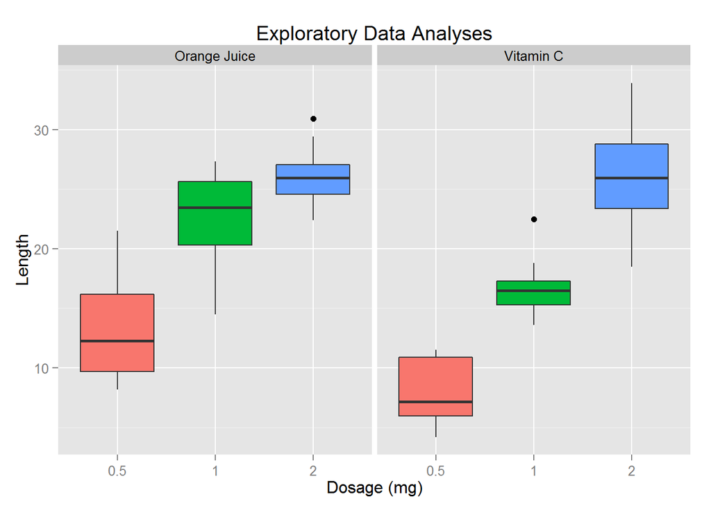

```r
library(ggplot2)
plot <- ggplot(tg,
               aes(x=factor(dose),y=len,fill=factor(dose)))
plot <-plot + geom_boxplot(notch=F) +
      facet_grid(.~supp) +
       scale_x_discrete("Dosage (mg)") +
       scale_y_continuous("Length") +
       ggtitle("Exploratory Data Analyses") +
       theme(legend.position = "none")

print(plot)
```

## Statistical Inference and Analysis

### Dosage tests

In a first step, it is natural to verify whether the dosage of the supplement affects the toothgrowth irregardless of the supplement. Since we have 3 dose sets, we will compare the effects of .5mg to 1.0mg dose, 1.0mg to 2.0 dose, and .5mg to 2.0 dose.

```r
t1 <- filter(tg, dose == "0.5")$len #low dose group
t2 <- filter(tg, dose == "1")$len   #medium dose group
t3 <- filter(tg, dose == "2")$len   #large dose group

t1vt2 <- t.test(t1,t2, paired = FALSE, var.equal = FALSE, alternative="two.sided")
t1vt2 #t1 vs t2 group
```

```
##
##  Welch Two Sample t-test
##
## data:  t1 and t2
## t = -6.4766, df = 37.986, p-value = 1.268e-07
## alternative hypothesis: true difference in means is not equal to 0
## 95 percent confidence interval:
##  -11.983781  -6.276219
## sample estimates:
## mean of x mean of y
##    10.605    19.735
```

The test to compare .5 and 1.0mg dose rejects the null hypothesis. The very small p-value leads us to accept the alternative hyposthesis that their means is not equal to 0 and infer that these two samples are different.

```r
t2vt3 <- t.test(t2,t3, paired = FALSE, var.equal = FALSE, alternative="two.sided")
t2vt3 #t2 vs t3 group
```

```
##
##  Welch Two Sample t-test
##
## data:  t2 and t3
## t = -4.9005, df = 37.101, p-value = 1.906e-05
## alternative hypothesis: true difference in means is not equal to 0
## 95 percent confidence interval:
##  -8.996481 -3.733519
## sample estimates:
## mean of x mean of y
##    19.735    26.100
```

For this test to compare 1mg to 2mg dose still rejects that null hypothesis. The p-values is still very small which means that these 2 groups are different.

```r
t1vt3 <- t.test(t1,t3, paired = FALSE, var.equal = FALSE, alternative="two.sided")
t1vt3 #t1 vs t3 group
```

```
##
##  Welch Two Sample t-test
##
## data:  t1 and t3
## t = -11.799, df = 36.883, p-value = 4.398e-14
## alternative hypothesis: true difference in means is not equal to 0
## 95 percent confidence interval:
##  -18.15617 -12.83383
## sample estimates:
## mean of x mean of y
##    10.605    26.100
```

Just for verifying that these two groups are different as well.

All of the test doesn’t contain 0 in their confidence intervals which can ultimately infer that these groups are all different. It indicates that administration of ascorbic acid will affect toothgrowth depending on tested dosage levels.

### Supplement type effectivity tests

On this part, we check the effects of toothgrowth for the two supplement types.

```r
t1OJ <- filter(tg, dose == "0.5",supp == "Orange Juice")$len #low dose group
t1VC <- filter(tg, dose == "0.5",supp == "Vitamin C")$len    #medium dose group

t1supp <- t.test(t1OJ,t1VC, paired = FALSE, var.equal = FALSE, alternative="two.sided")
t1supp
```

```
##
##  Welch Two Sample t-test
##
## data:  t1OJ and t1VC
## t = 3.1697, df = 14.969, p-value = 0.006359
## alternative hypothesis: true difference in means is not equal to 0
## 95 percent confidence interval:
##  1.719057 8.780943
## sample estimates:
## mean of x mean of y
##     13.23      7.98
```

The test result shows that Orange Juice yields longer toothgrowth over Vitamin C. At 95% of the time, we can expect an interval of 1.71 to 8.78 difference for the two types.

```r
t2OJ <- filter(tg, dose == "1",supp == "Orange Juice")$len #low dose group
t2VC <- filter(tg, dose == "1",supp == "Vitamin C")$len    #medium dose group

t2supp <- t.test(t2OJ,t2VC, paired = FALSE, var.equal = FALSE, alternative="two.sided")
t2supp
```

```
##
##  Welch Two Sample t-test
##
## data:  t2OJ and t2VC
## t = 4.0328, df = 15.358, p-value = 0.001038
## alternative hypothesis: true difference in means is not equal to 0
## 95 percent confidence interval:
##  2.802148 9.057852
## sample estimates:
## mean of x mean of y
##     22.70     16.77
```

The test results shows the Orange Juice yields longer toothgrowth over Vitamin C as well. At 95% of the time, we can expect an interval of 2.8 to 9.0 difference for the two types.

```r
t3OJ <- filter(tg, dose == "2",supp == "Orange Juice")$len #low dose group
t3VC <- filter(tg, dose == "2",supp == "Vitamin C")$len    #medium dose group

t3supp <- t.test(t3OJ,t3VC, paired = FALSE, var.equal = FALSE, alternative="two.sided")
t3supp
```

```
##
##  Welch Two Sample t-test
##
## data:  t3OJ and t3VC
## t = -0.0461, df = 14.04, p-value = 0.9639
## alternative hypothesis: true difference in means is not equal to 0
## 95 percent confidence interval:
##  -3.79807  3.63807
## sample estimates:
## mean of x mean of y
##     26.06     26.14
```

At 2mg dose, the effects of the two supplements doesn’t yield much of a difference. They have the same effect at this dosage level.

## Conclusion

The effects of Ascorbic acid on toothgrowth indicates considerable increase in length when administered in progressive dosage levels. However, comparing the supplement types seems to have different effects over the other at certain dosage level. At .5 and 1mg level, Orange Juice yields longer toothgrowth over Vitamin C. But at 2mg level, the effects seems to be similar.

#### Reproducible code: [link](https://github.com/HashDevRunner/statsinferenceproj)